# Take-home assignment 2

John Palmer

### Set-up

This chunk contains some code needed to re-format the data frame for this exercise:

```r
# This code is here to pre-load the rice microbiome data
# !!! YOU WILL NEED TO MODIFY THESE FILE PATHS !!!
rice <- read.csv('~/BIO9919/arbuckle1.csv')
otu <- read.csv('~/BIO9919/soilOTUs.csv')

# these lines map some columns from `otu` to `rice`
index <- match(rice$variable, otu$OTU)
rice$Phylum <- otu$Phylum[index]

# create a list keyed by Phylum and Compartment
temp <- split(rice$RA, f=list(rice$Phylum, rice$Compartment))
means <- sapply(temp, mean)
dim(means) <- c(12,3)  # fold into a matrix

# divide each column by its total
freqs <- sweep(means, 2, apply(means, 2, sum), '/')
```

### Questions

#### Relative abundance

1. For this first part, we’re going to examine the relative abundance variable (`RA`). This quantity is proportional to the ratio of `Depth` (the number of short reads for that sample) and `value` (the number of those reads that mapped to a particular OTU). Generate a visual confirmation of this with a scatterplot that displays this ratio on the x-axis, and `RA` on the y-axis:

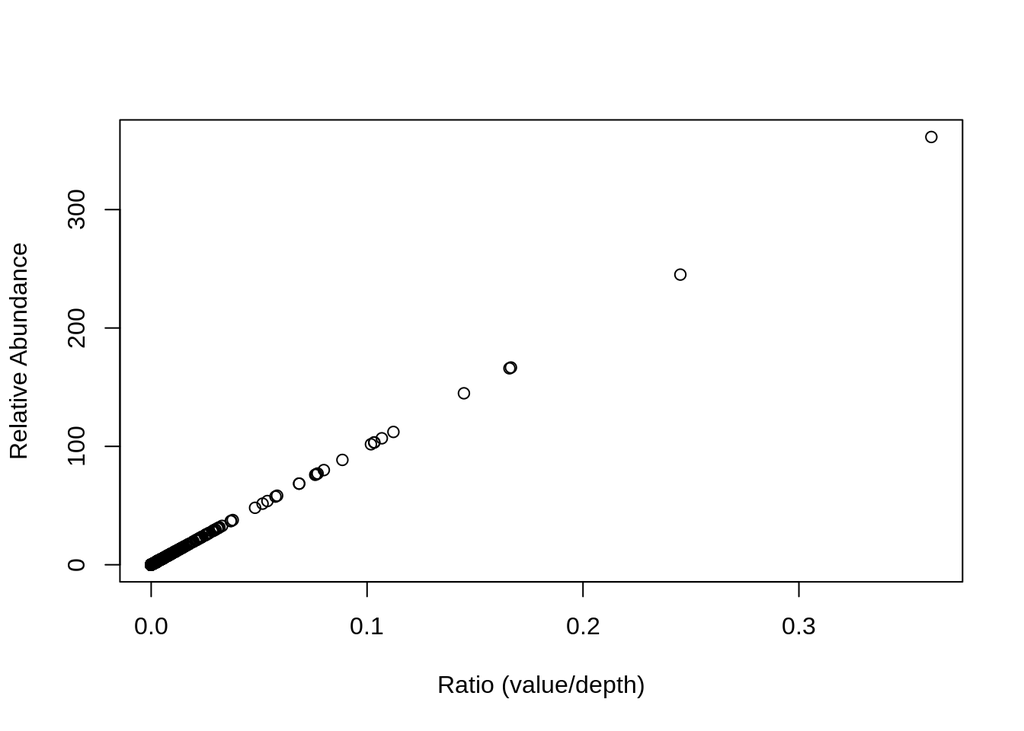

```r
# make a plot!
plot(rice$value/rice$Depth, rice$RA, ylab="Relative Abundance",xlab="Ratio (value/depth)")
```

2. To get a better understanding of `RA`, let’s generate a histogram. Make one below:

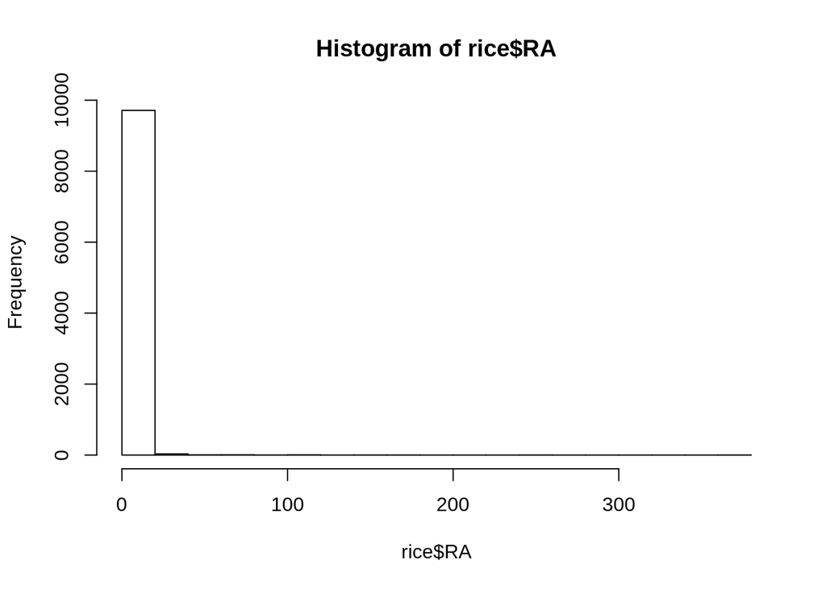

```r
# Make a histogram!
hist(rice$RA)
```

3. This is a really skewed distribution! We’d like to use a log-transform, but first we should determine how many of the values in the vector `RA` are equal to zero. Use the `table` command and a logical test to determine this number:

```r
# how many zeroes?
zeros <- rice$RA == 0
table(zeros)
```

```
## zeros
## FALSE  TRUE
##  6219  3549
```

4. Bearing this in mind, go ahead and make a histogram with the $\log_{10}$-transformed `RA` vector. Add a “rug” and a density curve to this histogram, remove the title, make the x-axis label more informative, and make use of colour to distinguish the density from the histogram:

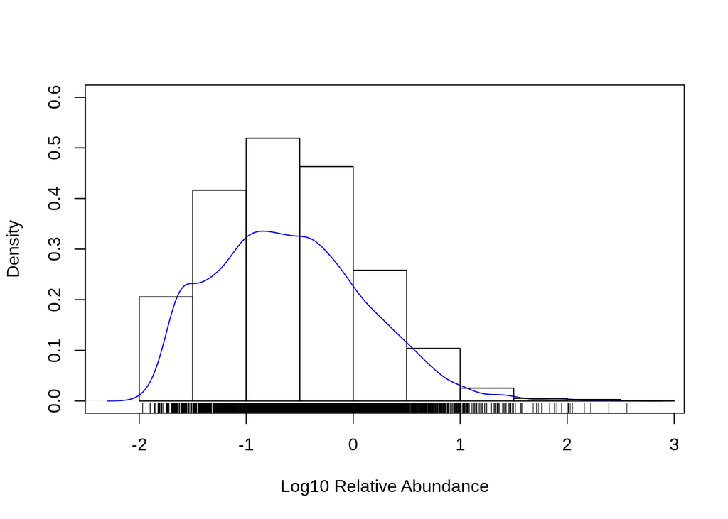

```r
# Response here
logRA <- log10(rice$RA)
plot(density(logRA), ylim=c(0,0.6), col=rgb(0,0,0.9), main="", xlab="Log10 Relative Abundance")
hist(logRA, add=T, freq=F)
rug(logRA)
```

#### Rice microbiome

For this next set of questions, we’re going to recreate a figure from a [PNAS paper](https://www.pnas.org/content/112/8/E911) associated with this data set. In the “Set-Up” section above, I’ve created a matrix for you (`freqs`) that contains the relative frequency of different bacterial phyla in the different root compartments (in increasing distance away from the centre of the root: endosphere, rhizoplane, rhiszosphere).

5. Create a plain stacked barplot of phyla frequencies against compartments using the matrix `freqs`:

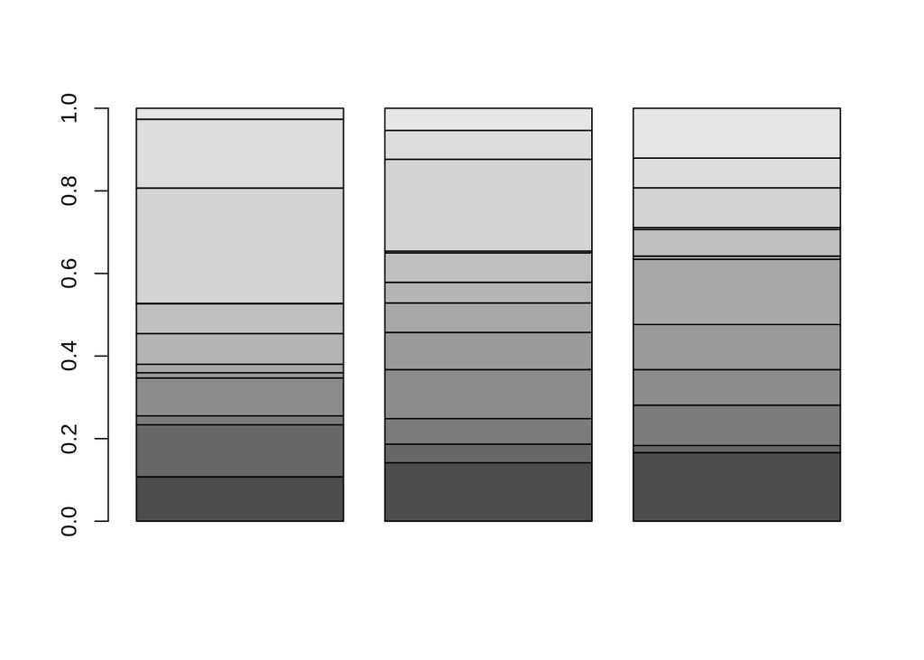

```r
# Response here!
barplot(freqs)
```

6. Next, let’s label these stacks. Each stack represents a `Compartment` - by default, R will arrange these in left to right in the order of the factor levels. You can retrieve the levels of a factor vector as a character vector with the function `levels`. Get this vector and pass it to your `barplot` function for the optional argument `names.arg`:

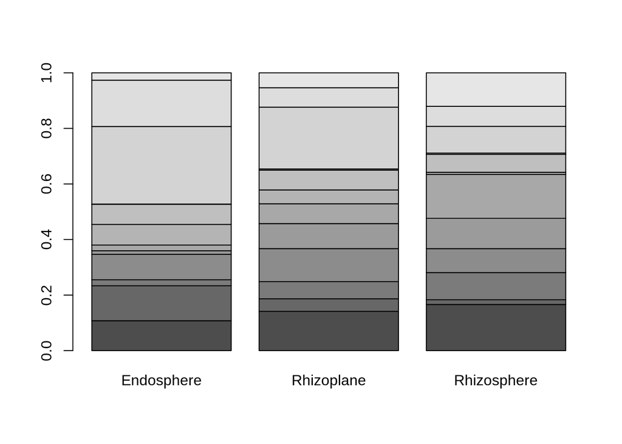

```r
# Response here!

barplot(freqs, names.arg=levels(rice$Compartment))
```

7. Let’s add some colour. Use `RColorBrewer` to generate a palette and apply it to your barplot with the keyward argument `col` (note there are 12 phyla):

```r
# Response here!
require(RColorBrewer)
```

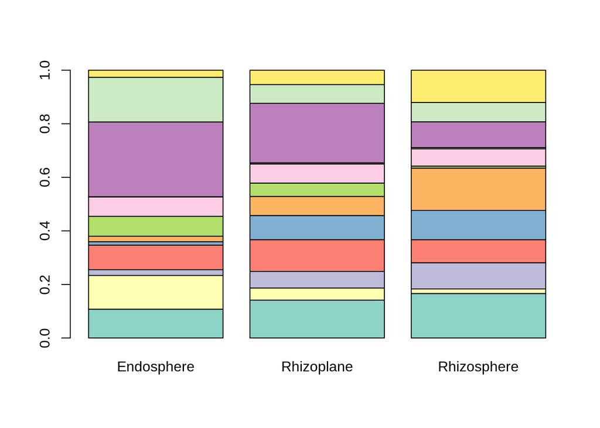

```r
pal <- brewer.pal(n=12, name="Set3")
barplot(freqs, names.arg=levels(rice$Compartment), col=pal)
```

Make use of the `help` command and the course readings!

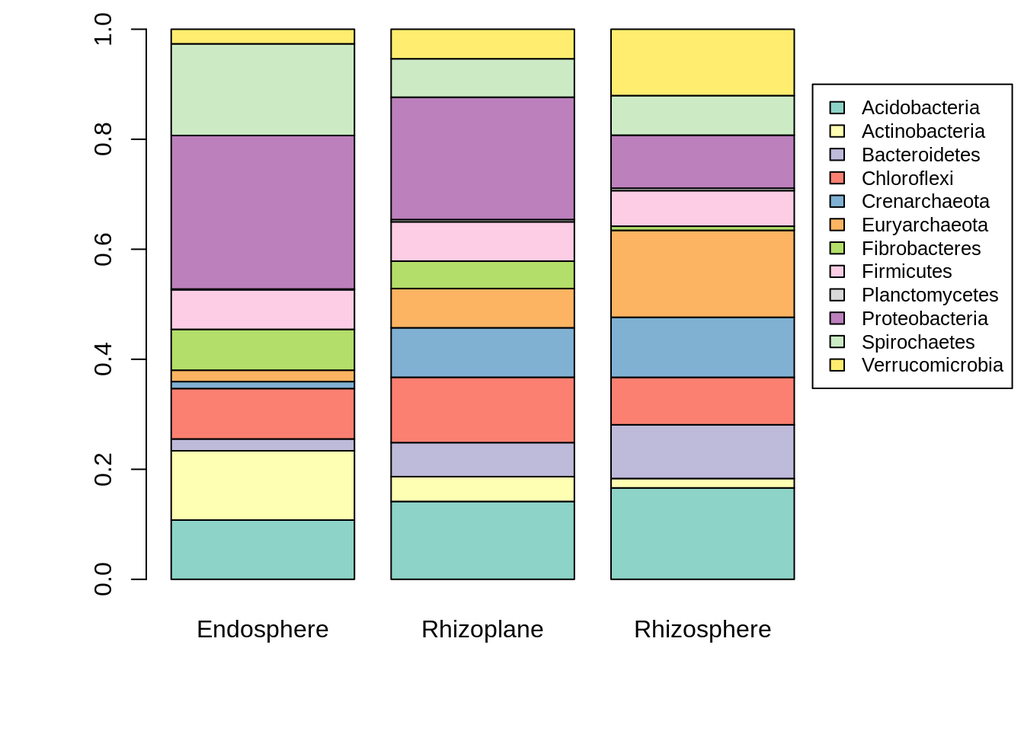

```r
# Response here!
require(RColorBrewer)
pal <- brewer.pal(n=12, name="Set3")
phyla <- levels(rice$Phylum)
par(mar=c(5,5,1,7))
par(xpd=NA)
barplot(freqs, names.arg=levels(rice$Compartment), col=pal)
legend(3.7,0.9,legend=phyla, fill=pal,cex=0.8)
```

Save your plot as a PDF file and attach it to your assignment! You will be judged on the quality of your barplot.